# Olympic Games dataset analysis

Kirill Kirilenko

# Preparation

To run this script just choose your working directory where the data is located

```r
working_dir <- '~/Bioinformatics_Institute/Statistiks-and-R-programming/project1/'
```

Load packages and data

```r
required_packages <- c('plyr', 'readr', 'dplyr', 'tidyr', 'stringr','purrr',
                       'ggplot2','ggthemes', 'nortest','forcats')
for (p in required_packages) {
  if(!require(p,character.only = TRUE)) {
    install.packages(p, dep = TRUE,repos = "http://cran.us.r-project.org")
  }
}
```

```r
library(plyr)
library(readr)
library(dplyr)
library(tidyr)
library(stringr)
library(purrr)
library(ggplot2)
library(ggthemes)
library(nortest)
library(forcats)
```

## I) Create a function to process .csv files

```r
load_data <- function(directory,extension = '.csv'){
  files <- list.files(path=directory, pattern=extension, full.names=TRUE)
  df <-ldply(files, read_csv)
}
```

```r
olympic_games <- load_data(working_dir) # it may take a moment
```

First look at the data:

```r
head(olympic_games)
```

```
##   ID                     Name Sex Age Height Weight           Team NOC
## 1  1                A Dijiang   M  24    180     80          China CHN
## 2  2                 A Lamusi   M  23    170     60          China CHN
## 3  3      Gunnar Nielsen Aaby   M  24     NA     NA        Denmark DEN
## 4  4     Edgar Lindenau Aabye   M  34     NA     NA Denmark/Sweden DEN
## 5  5 Christine Jacoba Aaftink   F  21    185     82    Netherlands NED
## 6  5 Christine Jacoba Aaftink   F  21    185     82    Netherlands NED
##         Games Year Season      City         Sport
## 1 1992 Summer 1992 Summer Barcelona    Basketball
## 2 2012 Summer 2012 Summer    London          Judo
## 3 1920 Summer 1920 Summer Antwerpen      Football
## 4 1900 Summer 1900 Summer     Paris    Tug-Of-War
## 5 1988 Winter 1988 Winter   Calgary Speed Skating
## 6 1988 Winter 1988 Winter   Calgary Speed Skating
##                                Event Medal ...1 ...17 Height_z_scores
## 1        Basketball Men's Basketball  <NA>   NA    NA              NA
## 2       Judo Men's Extra-Lightweight  <NA>   NA    NA              NA
## 3            Football Men's Football  <NA>   NA    NA              NA
## 4        Tug-Of-War Men's Tug-Of-War  Gold   NA    NA              NA
## 5   Speed Skating Women's 500 metres  <NA>   NA    NA              NA
## 6 Speed Skating Women's 1,000 metres  <NA>   NA    NA              NA
##   Height_min_max_scaled
## 1                    NA
## 2                    NA
## 3                    NA
## 4                    NA
## 5                    NA
## 6                    NA
```

```r
str(olympic_games)
```

```
## 'data.frame':    813345 obs. of  19 variables:
##  $ ID                   : num  1 2 3 4 5 5 5 5 5 5 ...
##  $ Name                 : chr  "A Dijiang" "A Lamusi" "Gunnar Nielsen Aaby" "Edgar Lindenau Aabye" ...
##  $ Sex                  : chr  "M" "M" "M" "M" ...
##  $ Age                  : num  24 23 24 34 21 21 25 25 27 27 ...
##  $ Height               : num  180 170 NA NA 185 185 185 185 185 185 ...
##  $ Weight               : num  80 60 NA NA 82 82 82 82 82 82 ...
##  $ Team                 : chr  "China" "China" "Denmark" "Denmark/Sweden" ...
##  $ NOC                  : chr  "CHN" "CHN" "DEN" "DEN" ...
##  $ Games                : chr  "1992 Summer" "2012 Summer" "1920 Summer" "1900 Summer" ...
##  $ Year                 : num  1992 2012 1920 1900 1988 ...
##  $ Season               : chr  "Summer" "Summer" "Summer" "Summer" ...
##  $ City                 : chr  "Barcelona" "London" "Antwerpen" "Paris" ...
##  $ Sport                : chr  "Basketball" "Judo" "Football" "Tug-Of-War" ...
##  $ Event                : chr  "Basketball Men's Basketball" "Judo Men's Extra-Lightweight" "Football Men's Football" "Tug-Of-War Men's Tug-Of-War" ...
##  $ Medal                : chr  NA NA NA "Gold" ...
##  $ ...1                 : num  NA NA NA NA NA NA NA NA NA NA ...
##  $ ...17                : num  NA NA NA NA NA NA NA NA NA NA ...
##  $ Height_z_scores      : num  NA NA NA NA NA NA NA NA NA NA ...
##  $ Height_min_max_scaled: num  NA NA NA NA NA NA NA NA NA NA ...
```

```r
summary(olympic_games)
```

```
##        ID             Name               Sex                 Age
##  Min.   :     1   Length:813345      Length:813345      Min.   : 10.00
##  1st Qu.: 34643   Class :character   Class :character   1st Qu.: 21.00
##  Median : 68205   Mode  :character   Mode  :character   Median : 24.00
##  Mean   : 68249                                         Mean   : 25.56
##  3rd Qu.:102097                                         3rd Qu.: 28.00
##  Max.   :135571                                         Max.   :240.00
##                                                         NA's   :28428
##      Height           Weight           Team               NOC
##  Min.   :127.0    Min.   :  7.0    Length:813345      Length:813345
##  1st Qu.:168.0    1st Qu.: 60.0    Class :character   Class :character
##  Median :175.0    Median : 70.0    Mode  :character   Mode  :character
##  Mean   :175.3    Mean   : 70.7
##  3rd Qu.:183.0    3rd Qu.: 79.0
##  Max.   :340.0    Max.   :214.0
##  NA's   :180518   NA's   :188628
##     Games                Year         Season              City
##  Length:813345      Min.   :1896   Length:813345      Length:813345
##  Class :character   1st Qu.:1960   Class :character   Class :character
##  Mode  :character   Median :1988   Mode  :character   Mode  :character
##                     Mean   :1978
##                     3rd Qu.:2002
##                     Max.   :2016
##                     NA's   :21
##     Sport              Event              Medal                ...1
##  Length:813345      Length:813345      Length:813345      Min.   :     1
##  Class :character   Class :character   Class :character   1st Qu.:135558
##  Mode  :character   Mode  :character   Mode  :character   Median :271116
##                                                           Mean   :271116
##                                                           3rd Qu.:406673
##                                                           Max.   :542230
##                                                           NA's   :271115
##      ...17        Height_z_scores  Height_min_max_scaled
##  Min.   :     1   Min.   :-4.6     Min.   :0.0
##  1st Qu.: 67780   1st Qu.:-0.7     1st Qu.:0.4
##  Median :135558   Median : 0.0     Median :0.5
##  Mean   :135558   Mean   : 0.0     Mean   :0.5
##  3rd Qu.:203336   3rd Qu.: 0.7     3rd Qu.:0.6
##  Max.   :271115   Max.   : 4.8     Max.   :1.0
##  NA's   :542230   NA's   :391461   NA's   :391461
```

## II) Check if data is correct. Cleaning data

How many NA-values in our data?

```r
colSums(is.na(olympic_games))
```

```
##                    ID                  Name                   Sex
##                     0                     3                    10
##                   Age                Height                Weight
##                 28428                180518                188628
##                  Team                   NOC                 Games
##                     9                    12                    15
##                  Year                Season                  City
##                    21                    21                    21
##                 Sport                 Event                 Medal
##                    21                    24                693999
##                  ...1                 ...17       Height_z_scores
##                271115                542230                391461
## Height_min_max_scaled
##                391461
```

Oh, we can’t just delete rows with NA-values, so we will lose most of the data.

```r
olympic_games$Sex <- factor(olympic_games$Sex)
olympic_games$Season <- factor(olympic_games$Season)
olympic_games$Medal <- factor(olympic_games$Medal)
```

Look at the categorical data:

```r
apply(olympic_games[,c(3,11,15)], 2, function(x) unique(x)) # We can see invalid value "G" in the Sex column
```

```
## $Sex
## [1] "M" "F" "G" NA
##
## $Season
## [1] "Summer" "Winter" NA
##
## $Medal
## [1] NA       "Gold"   "Bronze" "Silver"
```

```r
length(which(olympic_games$Sex == 'G'))
```

```
## [1] 2
```

So, change “G” to NA in the Sex variable

```r
olympic_games$Sex <- factor(replace(olympic_games$Sex, olympic_games$Sex == 'G', NA))
str(olympic_games$Sex)
```

```
##  Factor w/ 2 levels "F","M": 2 2 2 2 1 1 1 1 1 1 ...
```

Now let’s look at the numeric variables

1. A **Height** variable

```r
summary(olympic_games$Height)
```

```
##    Min. 1st Qu.  Median    Mean 3rd Qu.    Max.    NA's
##   127.0   168.0   175.0   175.3   183.0   340.0  180518
```

```r
sum(olympic_games$Height > 240, na.rm = T) # delete this value
```

```
## [1] 1
```

```r
olympic_games$Height[olympic_games$Height > 240] <- NA
```

2. A **Weight** variable

```r
summary(olympic_games$Weight)
```

```
##    Min. 1st Qu.  Median    Mean 3rd Qu.    Max.    NA's
##     7.0    60.0    70.0    70.7    79.0   214.0  188628
```

```r
sum(olympic_games$Weight < 30, na.rm = T)
```

```
## [1] 63
```

```r
olympic_games$Name[which(olympic_games$Weight < 20)]
```

```
## [1] "Helmut Lehmann" "Helmut Lehmann" "Helmut Lehmann"
```

```r
# Change his weight to NA
olympic_games$Weight[olympic_games$Weight > 240] <- NA
```

3. An **Age** variable

We found out on the web that the youngest Olympic competitor was 10 years old And the oldest one was 72 y.o. (look here https://edition.cnn.com/2021/08/04/sport/youngest-oldest-olympians-spt-intl/index.html)

```r
summary(olympic_games$Age)
```

```
##    Min. 1st Qu.  Median    Mean 3rd Qu.    Max.    NA's
##   10.00   21.00   24.00   25.56   28.00  240.00   28428
```

```r
sum(olympic_games$Age > 72, na.rm = T)
```

```
## [1] 135
```

4. A **Games** variable

```r
unique(olympic_games$Games)
```

```
##  [1] "1992 Summer" "2012 Summer" "1920 Summer" "1900 Summer" "1988 Winter"
##  [6] "1992 Winter" "1994 Winter" "1932 Summer" "2002 Winter" "1952 Summer"
## [11] "1980 Winter" "2000 Summer" "1996 Summer" "1912 Summer" "1924 Summer"
## [16] "2014 Winter" "1948 Summer" "1998 Winter" "2006 Winter" "2008 Summer"
## [21] "2016 Summer" "2004 Summer" "1960 Winter" "1964 Winter" "1984 Winter"
## [26] "1984 Summer" "1968 Summer" "1972 Summer" "1988 Summer" "1936 Summer"
## [31] "1952 Winter" "1956 Winter" "1956 Summer" "1960 Summer" "1928 Summer"
## [36] "1976 Summer" "1980 Summer" "1964 Summer" "2010 Winter" "1968 Winter"
## [41] "1906 Summer" "1972 Winter" "1976 Winter" "1924 Winter" "1904 Summer"
## [46] "1928 Winter" "1908 Summer" "1948 Winter" "1932 Winter" "1936 Winter"
## [51] "1896 Summer" "2000 Su"     "2004 Summe"  NA
```

We change value “2000 Su” to 2000 Summer and “2004 Summe” to 2004 Summer

```r
olympic_games$Games[olympic_games$Games == "2000 Su"] <- "2000 Summer"
olympic_games$Games[olympic_games$Games == "2004 Summe"] <- "2004 Summer"
```

5. A **Year** variable

```r
sort(unique(olympic_games$Year))
```

```
##  [1] 1896 1900 1904 1906 1908 1912 1920 1924 1928 1932 1936 1948 1952 1956 1960
## [16] 1964 1968 1972 1976 1980 1984 1988 1992 1994 1996 1998 2000 2002 2004 2006
## [31] 2008 2010 2012 2014 2016
```

It’s OK!

6. A **Season** variable

```r
unique(olympic_games$Season)
```

```
## [1] Summer Winter <NA>
## Levels: Summer Winter
```

And this one is OK!

7. A **City** variable

```r
table(olympic_games$City)
```

```
##
##            Albertville              Amsterdam              Antwerpen
##                  10308                  14976                  12876
##                 Athina                Atlanta              Barcelona
##                  46662                  41337                  38931
##                Beijing                 Berlin                Calgary
##                  40806                  19518                   7917
##               Chamonix      Cortina d'Ampezzo Garmisch-Partenkirchen
##                   1380                   3921                   2685
##               Grenoble               Helsinki              Innsbruck
##                   5673                  24810                  10917
##            Lake Placid            Lillehammer                 London
##                   6294                   9480                  67275
##            Los Angeles              Melbourne            Mexico City
##                  37266                  14487                  25764
##               Montreal                 Moskva                 Munich
##                  25923                  21573                  30912
##                 Nagano                   Oslo                  Paris
##                  10815                   3264                  21507
##         Rio de Janeiro                   Roma         Salt Lake City
##                  41064                  24354                  12327
##           Sankt Moritz                Sapporo               Sarajevo
##                   4971                   4965                   6402
##                  Seoul                  Sochi           Squaw Valley
##                  36111                  14673                   3348
##              St. Louis              Stockholm                 Sydney
##                   3903                  13011                  41460
##                  Tokyo                 Torino              Vancouver
##                  23106                  13146                  13206
```

OK again!

8. A **Sport** variable

```r
table(olympic_games$Sport)
```

```
##
##               Aeronautics             Alpine Skiing                  Alpinism
##                         3                     26487                        75
##                   Archery          Art Competitions                 Athletics
##                      7002                     10734                    115869
##                 Badminton                  Baseball                Basketball
##                      4371                      2682                     13605
##             Basque Pelota          Beach Volleyball                  Biathlon
##                         6                      1692                     14679
##                 Bobsleigh                    Boxing                  Canoeing
##                      9174                     18141                     18510
##                   Cricket                   Croquet      Cross Country Skiing
##                        72                        57                     27399
##                   Curling                   Cycling                    Diving
##                      1389                     32577                      8526
##             Equestrianism                   Fencing            Figure Skating
##                     19032                     32202                      6894
##                    Footba                  Football          Freestyle Skiing
##                         1                     20231                      2811
##                      Golf                Gymnastics                  Handball
##                       741                     80118                     10995
##                    Hockey                Ice Hockey              Jeu De Paume
##                     16248                     16548                        33
##                      Judo                  Lacrosse                      Luge
##                     11403                       180                      4437
##       Military Ski Patrol         Modern Pentathlon              Motorboating
##                        72                      5031                        51
##           Nordic Combined                      Polo                  Racquets
##                      4032                       285                        36
##       Rhythmic Gymnastics                     Roque                    Rowing
##                      1974                        12                     31785
##                     Rugby              Rugby Sevens                   Sailing
##                       486                       897                     19758
##                  Shooting Short Track Speed Skating                  Skeleton
##                     34344                      4602                       597
##               Ski Jumping              Snowboarding                  Softball
##                      7203                      2808                      1434
##             Speed Skating                  Swimming     Synchronized Swimming
##                     16839                     69585                      2727
##              Table Tennis                 Taekwondo                    Tennis
##                      5865                      1818                      8586
##              Trampolining                 Triathlon                Tug-Of-War
##                       456                      1587                       510
##                Volleyball                Water Polo             Weightlifting
##                     10212                     11538                     11811
##                 Wrestling
##                     21459
```

Let’s change the value ‘Footba’ to Football

```r
olympic_games$Sport[olympic_games$Sport == 'Footba'] <- 'Football'
```

Here we created a function to catch the outliers:

```r
outliers <- function(df){
  df %>%
    select_if(is.numeric) %>%
    map(~ boxplot.stats(.x)$out)
}
```

Let’s look at the number of outliers in the numeric variables exclude a Year variable(we won’t delete the outliers).

```r
sapply(outliers(select(olympic_games, -Year)),function(x) length(x))
```

```
##                    ID                   Age                Height
##                     0                 30954                  4014
##                Weight                  ...1                 ...17
##                  9714                     0                     0
##       Height_z_scores Height_min_max_scaled
##                  2676                  2676
```

## III) The youngest athlete of the 1992 Olympics

1. The youngest Male athlete is **11**
2. The youngest Female athlete is **12**

## IV) Mean and sd of a Height variable for Male and Female athletes

1. Male

mean: **178.8585917**

sd: **9.3603522**

2. Female

mean: **167.8396064**

sd: **8.7784287**

## V) Mean and sd of a Height variable for Female tennis players in 2000

mean: **169**

sd: **9.5**

## VI) The heaviest athlete in 2006

```r
olympic_games %>%
  filter(Year == 2006) %>%
  slice_max(Weight) %>%
  select(Name,Weight)
```

```
##                Name Weight
## 1 Patrick R. Antaki    127
## 2 Patrick R. Antaki    127
## 3 Patrick R. Antaki    127
```

## VII) Number of gold medals earned by women from 1980 to 2010

```r
olympic_games %>%
  filter(Year >= 1980 & Year <= 2010 & Medal == 'Gold' & Sex == 'F') %>%
  select(Name) %>%
  summarise(n=n())
```

```
##      n
## 1 6747
```

## VIII) Count the years when John Aalberg was at the Olympics

```r
olympic_games %>%
  filter(Name == 'John Aalberg') %>%
  select(Year) %>%
  distinct()
```

```
##   Year
## 1 1992
## 2 1994
```

So, He participated at Olympiads twice

## IX) Identify the least and the most represented age groups of the Olympics in 2008

```r
olympic_grouped_2008 <- table(cut(olympic_games$Age[olympic_games$Year == 2008], c(14, 24, 34, 44,55)))
```

So, the most represented age group is **(24,34]**

The least is **(44,55]**

## X) The difference between number of Olympics Sport in 2002 and 1998

```r
length(na.omit(unique(olympic_games$Sport[olympic_games$Year == 2002]))) - length(na.omit(unique(olympic_games$Sport[olympic_games$Year == 1998])))
```

```
## [1] 1
```

```r
winter_top <- na.omit(olympic_games %>% filter(Season == 'Winter') %>%
  select(Team, Medal) %>%
  group_by(Medal,Team) %>%
  summarise(n = n())) %>%
  slice_max(order_by = n, n = 1)
winter_top
```

```
## # A tibble: 3 × 3
## # Groups:   Medal [3]
##   Medal  Team              n
##   <fct>  <chr>         <int>
## 1 Bronze Finland         645
## 2 Gold   Canada          867
## 3 Silver United States   813
```

Summer:

```r
summer_top <- na.omit(olympic_games %>% filter(Season == 'Summer') %>%
  select(Team, Medal) %>%
  group_by(Medal,Team) %>%
  summarise(n = n())) %>%
  slice_max(order_by = n, n = 1)
summer_top
```

```
## # A tibble: 3 × 3
## # Groups:   Medal [3]
##   Medal  Team              n
##   <fct>  <chr>         <int>
## 1 Bronze United States  3336
## 2 Gold   United States  6999
## 3 Silver United States  3723
```

but according to https://www.statista.com/statistics/1101719/summer-olympics-all-time-medal-list-since-1892/ it is not true (idk why).

## XII) Create a new variable Height_z_scores

```r
olympic_games$Height_z_scores <- scale(olympic_games$Height)
```

## XIII) Create a new variable Height_min_max_scaled

```r
olympic_games$Height_min_max_scaled <- (olympic_games$Height - min(olympic_games$Height, na.rm = T))/(max(olympic_games$Height,na.rm = T) - min(olympic_games$Height, na.rm = T))
colnames(olympic_games)
```

```
##  [1] "ID"                    "Name"                  "Sex"
##  [4] "Age"                   "Height"                "Weight"
##  [7] "Team"                  "NOC"                   "Games"
## [10] "Year"                  "Season"                "City"
## [13] "Sport"                 "Event"                 "Medal"
## [16] "...1"                  "...17"                 "Height_z_scores"
## [19] "Height_min_max_scaled"
```

## XIV) Compare Height, Weight and Age of men and women

1. A **Height** variable

Look at the Q-Q-plot plotted on a variable **Height** in general

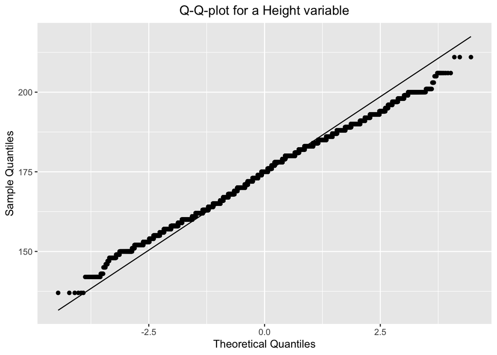

```r
winter_olympics <- filter(olympic_games,Season == 'Winter')
ggplot(winter_olympics,aes(sample = Height))+
  stat_qq()+
  stat_qq_line()+
  ggtitle('Q-Q-plot for a Height variable')+
  theme(plot.title = element_text(hjust = 0.5))+
  labs(x = "Theoretical Quantiles", y = "Sample Quantiles")
```

There are several ways to compare two variables. The most common t-test requires normal distribution. First check the normality of our variables:

We can’t use standard shapiro-test to normality test (because sample size > 5000, shapiro.test doesn’t support such large sample sizes).Let’s use Anderson-Darling normality test (from nortest library)

```r
ad.test(winter_olympics$Height[olympic_games$Sex == 'M'])
```

```
##
##  Anderson-Darling normality test
##
## data:  winter_olympics$Height[olympic_games$Sex == "M"]
## A = 228.61, p-value < 2.2e-16
```

```r
ad.test(winter_olympics$Height[olympic_games$Sex == 'F'])
```

```
##
##  Anderson-Darling normality test
##
## data:  winter_olympics$Height[olympic_games$Sex == "F"]
## A = 80.143, p-value < 2.2e-16
```

In both cases p << 0.01, thus we decided to use U-test:

```r
wilcox.test(Height~Sex, data = winter_olympics)
```

```
##
##  Wilcoxon rank sum test with continuity correction
##
## data:  Height by Sex
## W = 286400556, p-value < 2.2e-16
## alternative hypothesis: true location shift is not equal to 0
```

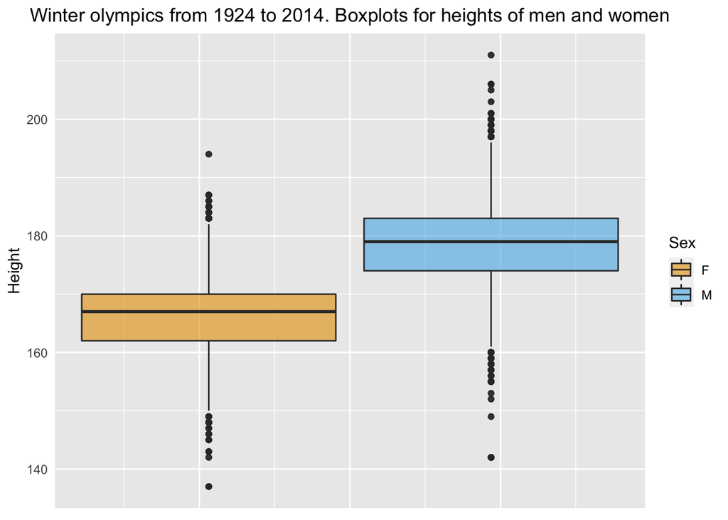

```r
winter_height <- ggplot(winter_olympics,aes(fill = Sex,y = Height))+
  geom_boxplot(alpha=0.6)+
  ggtitle('Winter olympics from 1924 to 2014. Boxplots for heights of men and women')+
  scale_fill_manual(values=c("#E69F00","#56B4E9"))+
  theme(plot.title = element_text(hjust = 0.5))

winter_height + theme(axis.text.x = element_blank(),
                      axis.ticks = element_blank())
```

2. A **Weight** variable

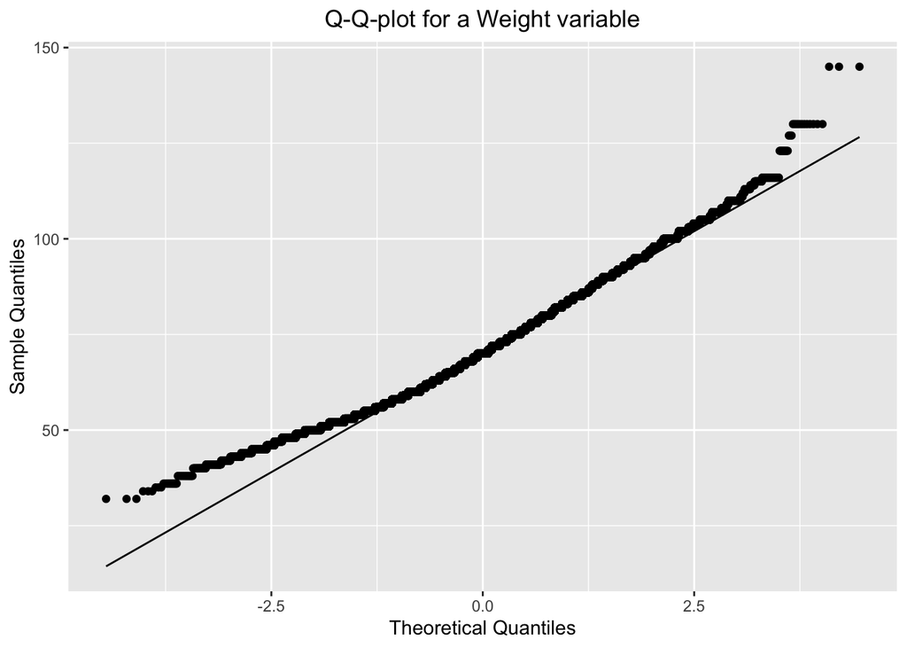

```r
ggplot(winter_olympics,aes(sample = Weight))+
  stat_qq()+
  stat_qq_line()+
  ggtitle('Q-Q-plot for a Weight variable')+
  theme(plot.title = element_text(hjust = 0.5))+
  labs(x = "Theoretical Quantiles", y = "Sample Quantiles")
```

And again we will use the Anderson-Darling normality test:

```r
ad.test(winter_olympics$Weight[olympic_games$Sex == 'M'])
```

```
##
##  Anderson-Darling normality test
##
## data:  winter_olympics$Weight[olympic_games$Sex == "M"]
## A = 241.4, p-value < 2.2e-16
```

```r
ad.test(winter_olympics$Weight[olympic_games$Sex == 'F'])
```

```
##
##  Anderson-Darling normality test
##
## data:  winter_olympics$Weight[olympic_games$Sex == "F"]
## A = 92.967, p-value < 2.2e-16
```

U-test:

```r
wilcox.test(Weight~Sex, data = winter_olympics)
```

```
##
##  Wilcoxon rank sum test with continuity correction
##
## data:  Weight by Sex
## W = 266252368, p-value < 2.2e-16
## alternative hypothesis: true location shift is not equal to 0
```

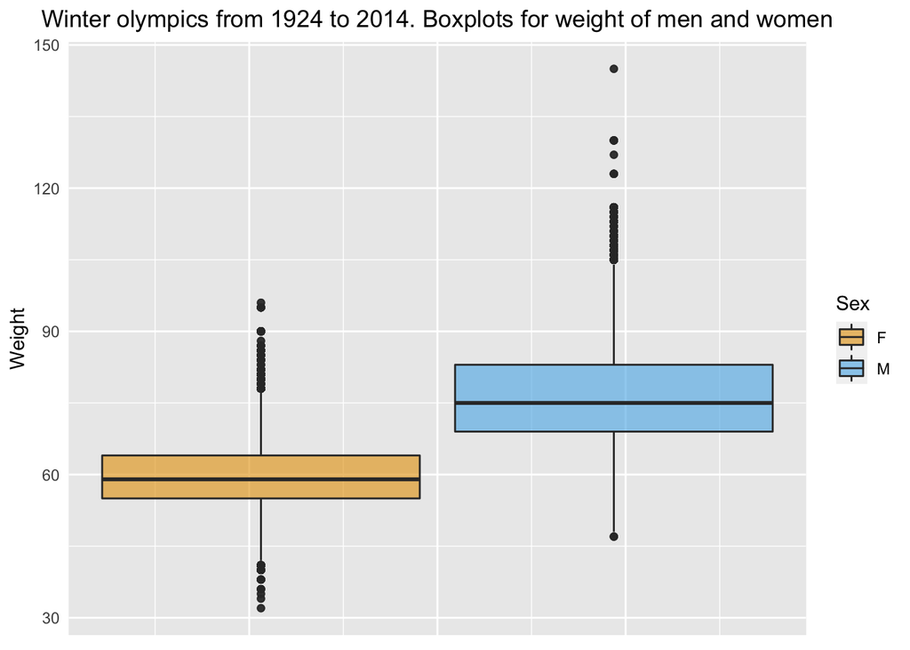

```r
winter_weight <- ggplot(winter_olympics,aes(fill = Sex,y = Weight))+
  geom_boxplot(alpha=0.6)+
  scale_fill_manual(values=c("#E69F00","#56B4E9"))+
  ggtitle('Winter olympics from 1924 to 2014. Boxplots for weight of men and women')+
  theme(plot.title = element_text(hjust = 0.5))

winter_weight + theme(axis.text.x = element_blank(),
               axis.ticks = element_blank())
```

3. An **Age** variable

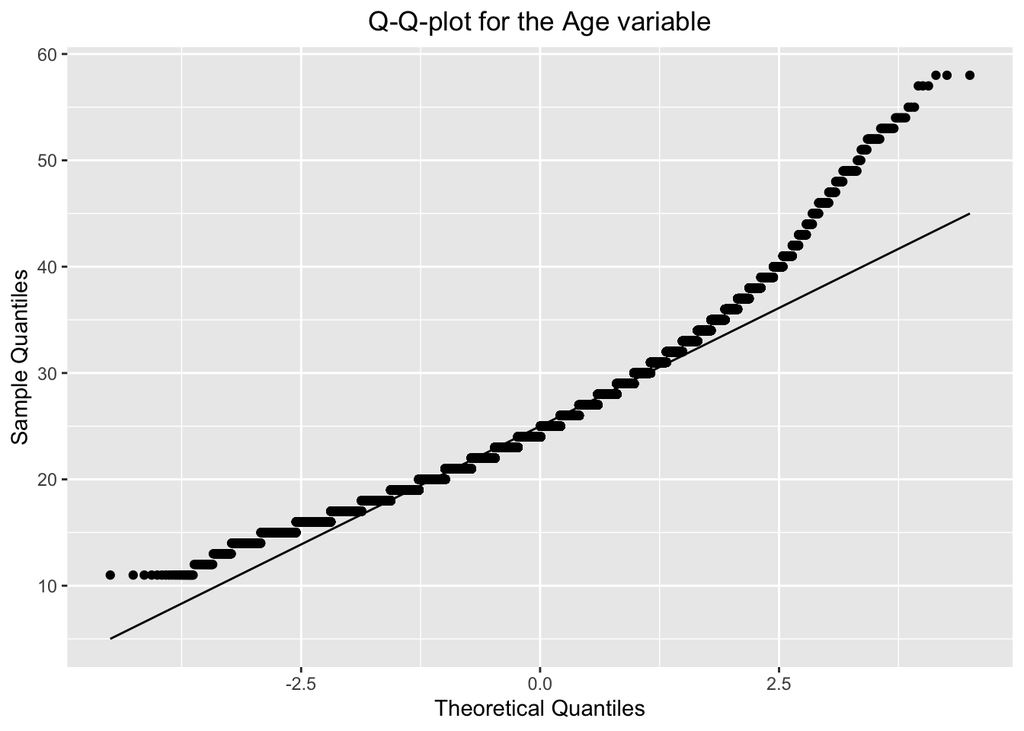

```r
ggplot(winter_olympics,aes(sample = Age))+
  stat_qq()+
  stat_qq_line()+
  ggtitle('Q-Q-plot for the Age variable')+
  theme(plot.title = element_text(hjust = 0.5))+
  labs(x = "Theoretical Quantiles", y = "Sample Quantiles")
```

the Anderson-Darling normality test:

```r
ad.test(winter_olympics$Age[olympic_games$Sex == 'M'])
```

```
##
##  Anderson-Darling normality test
##
## data:  winter_olympics$Age[olympic_games$Sex == "M"]
## A = 711.94, p-value < 2.2e-16
```

```r
ad.test(winter_olympics$Age[olympic_games$Sex == 'F'])
```

```
##
##  Anderson-Darling normality test
##
## data:  winter_olympics$Age[olympic_games$Sex == "F"]
## A = 259.76, p-value < 2.2e-16
```

U-test:

```r
wilcox.test(Age~Sex, data = winter_olympics)
```

```
##
##  Wilcoxon rank sum test with continuity correction
##
## data:  Age by Sex
## W = 1854361044, p-value < 2.2e-16
## alternative hypothesis: true location shift is not equal to 0
```

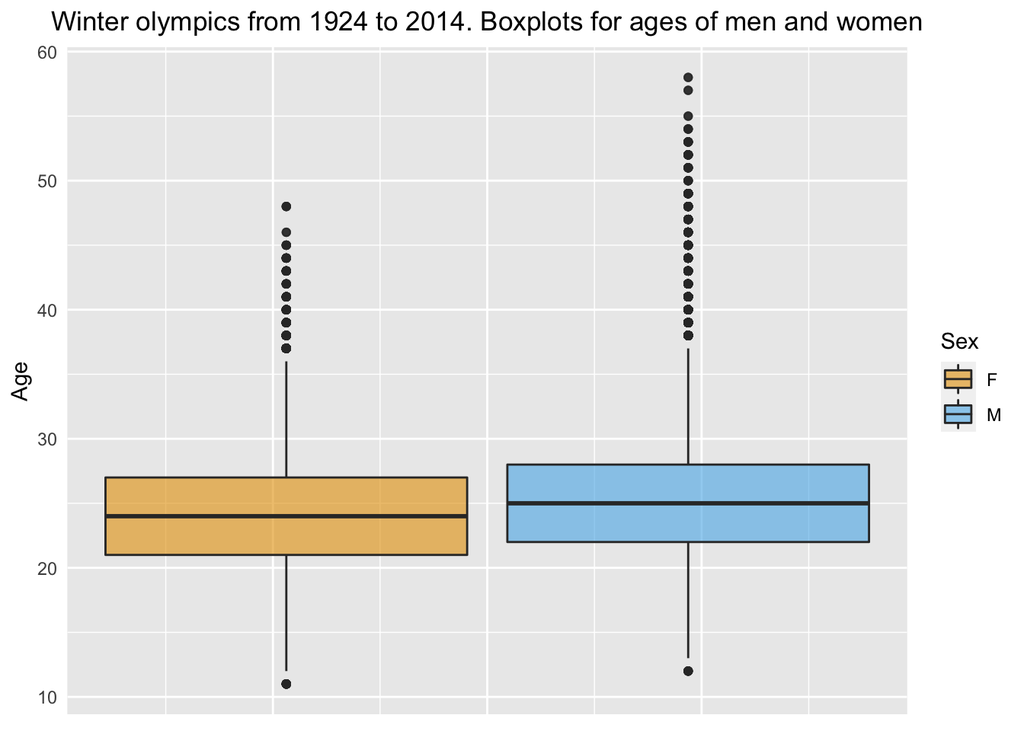

```r
winter_ages <- ggplot(winter_olympics,aes(fill = Sex,y = Age))+
  geom_boxplot(alpha=0.6)+
  ggtitle('Winter olympics from 1924 to 2014. Boxplots for ages of men and women')+
  scale_fill_manual(values=c("#E69F00","#56B4E9"))+
  theme(plot.title = element_text(hjust = 0.5))

winter_ages + theme(axis.text.x = element_blank(),
                    axis.ticks = element_blank())
```

Generally speaking we have entire populations and we just proved that there are all different. Let’s dive deeper in our analysis:

1. Look at the distribution of a **Height** varibale in different years

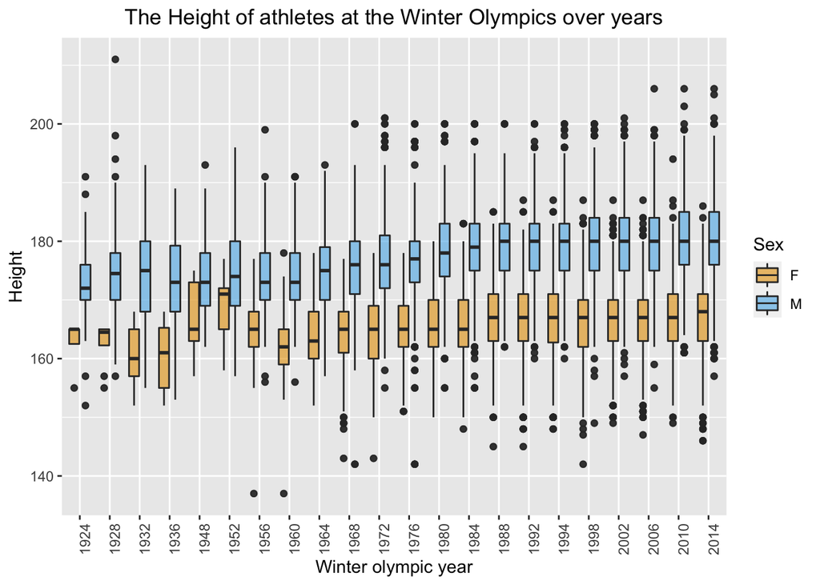

```r
winter_olympics %>% ggplot(aes(x=as.factor(Year), y=Height, fill=Sex)) +
  geom_boxplot(alpha=0.6) +
  xlab("Winter olympic year") + ylab("Height") +
  ggtitle('The Height of athletes at the Winter Olympics over years')+
  theme(plot.title = element_text(hjust = 0.5),
        axis.text.x = element_text(angle = 90))+
  scale_fill_manual(values=c("#E69F00","#56B4E9"))
```

2. A **Weight** variable:

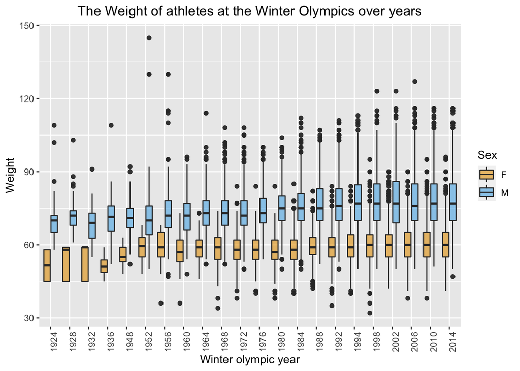

```r
winter_olympics %>% ggplot(aes(x=as.factor(Year), y=Weight, fill=Sex)) +
  geom_boxplot(alpha=0.6) +
  xlab("Winter olympic year") + ylab("Weight") +
  ggtitle('The Weight of athletes at the Winter Olympics over years')+
  theme(plot.title = element_text(hjust = 0.5),
        axis.text.x = element_text(angle = 90))+
  scale_fill_manual(values=c("#E69F00","#56B4E9"))
```

3. An **Age** variable

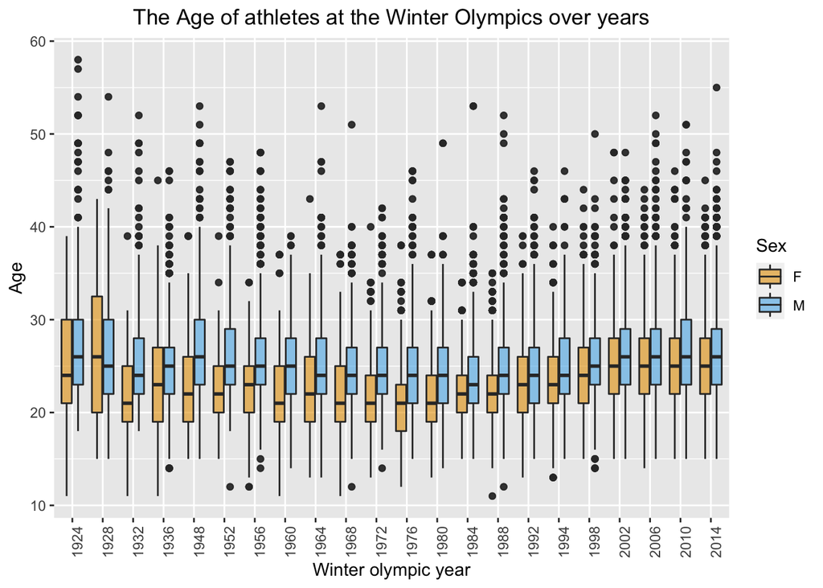

```r
winter_olympics %>% ggplot(aes(x=as.factor(Year), y=Age, fill=Sex)) +
  geom_boxplot(alpha=0.6) +
  xlab("Winter olympic year") + ylab("Age") +
  ggtitle('The Age of athletes at the Winter Olympics over years')+
  theme(plot.title = element_text(hjust = 0.5),
        axis.text.x = element_text(angle = 90))+
  scale_fill_manual(values=c("#E69F00","#56B4E9"))
```

Looking at the boxplots over years we found out that the less difference between F and M was in the variable Age (by Olympiads)

We think it is obvious that we have in all comparisons significant results: the sizes of groups are incredibly large.It seems it is better to compare more specific variables e.g. Age between F and M in 1952 for football athletes (see step XVI).

## XV) Find the relationships between Medal and Team variables

```r
table(olympic_games$Medal)
```

```
##
## Bronze   Gold Silver
##  39885  40116  39345
```

```r
length(unique(olympic_games$Team))
```

```
## [1] 1185
```

The null hypothesis here is that the two categories (Team and Medal) are independent.

```r
team_medal_data <- olympic_games %>%
  filter(!is.na(Medal)) %>%
  select(Medal,Team)

head(table(team_medal_data$Team,team_medal_data$Medal))
```

```
##
##                                Bronze Gold Silver
##   A North American Team            12    0      0
##   Afghanistan                       6    0      0
##   Algeria                          24   15     12
##   Ali-Baba II                      15    0      0
##   Amateur Athletic Association      0   15      0
##   Amstel Amsterdam                 12    0      0
```

```r
chisq.test(table(team_medal_data$Team,team_medal_data$Medal), simulate.p.value = TRUE,B=39782)
```

```
##
##  Pearson's Chi-squared test with simulated p-value (based on 39782
##  replicates)
##
## data:  table(team_medal_data$Team, team_medal_data$Medal)
## X-squared = 15880, df = NA, p-value = 2.514e-05
```

Visualization is the best way to reject the null hypothesis here:

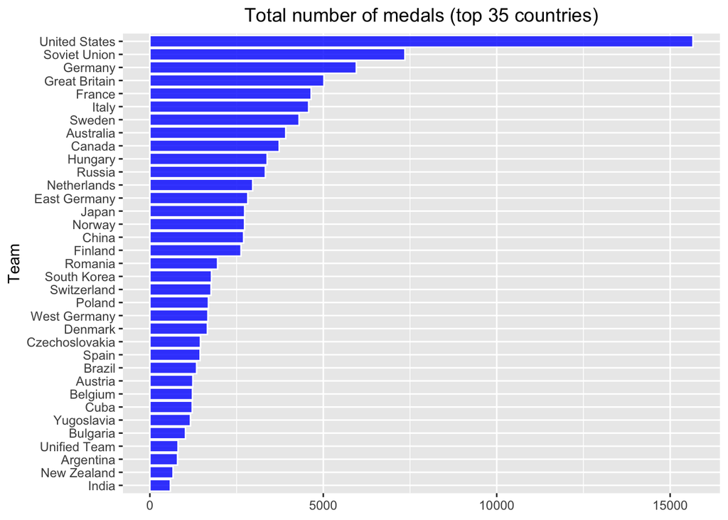

```r
medalsby_country <- team_medal_data %>% group_by(Team) %>%
  summarise(n = n()) %>%
  arrange(desc(n)) %>%
  slice(1:35)
medalsby_country$Team <- factor(medalsby_country$Team,levels = )

top_35<- medalsby_country %>%
  mutate(Team = fct_reorder(Team,n)) %>%
  ggplot(aes(x = Team, y = n)) +
  geom_col(fill="blue",color = 'white',alpha = 0.8) +
  coord_flip()+
  ggtitle('Total number of medals (top 35 countries)')+
  theme(plot.title = element_text(hjust = 0.5))
top_35 + theme(axis.title.x=element_blank())
```

## XVI) We decided to test more specific hypotheses:

1. Compare an Age variable between the men football athletes at the beginning of the 20th century and at the beginning of the 21th century

There are several ways to generate samples, we stopped on this: for the first group we took footballers from 1904 Olympiad and 1908 Olympiad, because later WWI had started, and two because sample sizes are small comparing to 20th century, and for the second from 2016 (just the latest presented).

Let’s visualize our data:

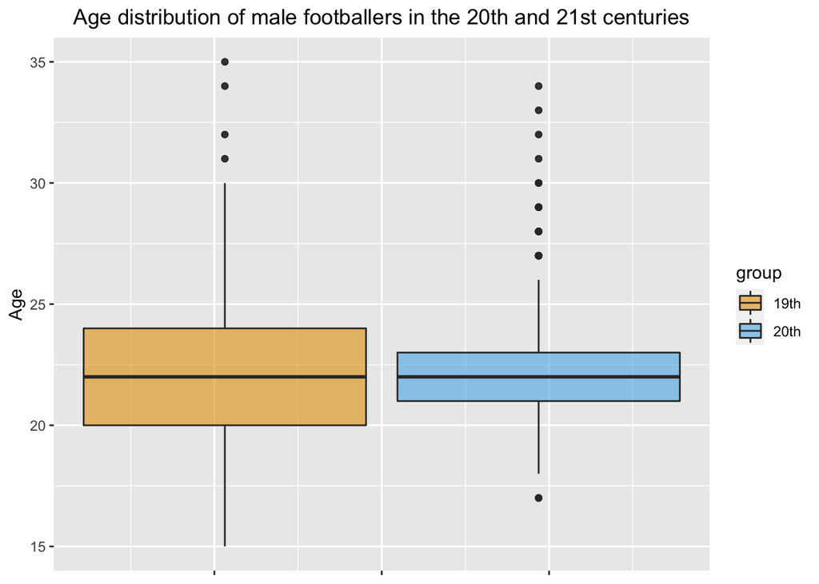

```r
football_dataset <- olympic_games %>%
  filter(Year %in% c(1904,1908,2016), Sport == 'Football', Sex == 'M')

football_dataset$group <- factor(ifelse(football_dataset$Year == 2016,'20th','19th'))

football_boxplots <- ggplot(football_dataset,aes(fill = group,y = Age))+
  geom_boxplot(alpha=0.6)+
  ggtitle('Age distribution of male footballers in the 20th and 21st centuries')+
  scale_fill_manual(values=c("#E69F00","#56B4E9"))+
  theme(plot.title = element_text(hjust = 0.5))
football_boxplots+ theme(axis.title.x=element_blank(),
                         axis.text.x=element_blank())
```

Perform normality-testing (here we will use shapiro-test):

```r
shapiro.test(football_dataset$Age[football_dataset$group == '19th'])
```

```
##
##  Shapiro-Wilk normality test
##
## data:  football_dataset$Age[football_dataset$group == "19th"]
## W = 0.96244, p-value = 9.52e-07
```

```r
shapiro.test(football_dataset$Age[football_dataset$group == '20th'])
```

```
##
##  Shapiro-Wilk normality test
##
## data:  football_dataset$Age[football_dataset$group == "20th"]
## W = 0.84128, p-value < 2.2e-16
```

```r
wilcox.test(football_dataset$Age[football_dataset$group == '19th'],
            football_dataset$Age[football_dataset$group == '20th'])
```

```
##
##  Wilcoxon rank sum test with continuity correction
##
## data:  football_dataset$Age[football_dataset$group == "19th"] and football_dataset$Age[football_dataset$group == "20th"]
## W = 120879, p-value = 0.229
## alternative hypothesis: true location shift is not equal to 0
```

2. Who weighs more female judo athletes or female volleyball players in 2012?

```r
volleyball_judo_subset <- olympic_games %>%
  filter(Year == '2012', Sport %in% c('Volleyball', "Judo"), Sex == 'F')
```

Again perform some boxplotting:

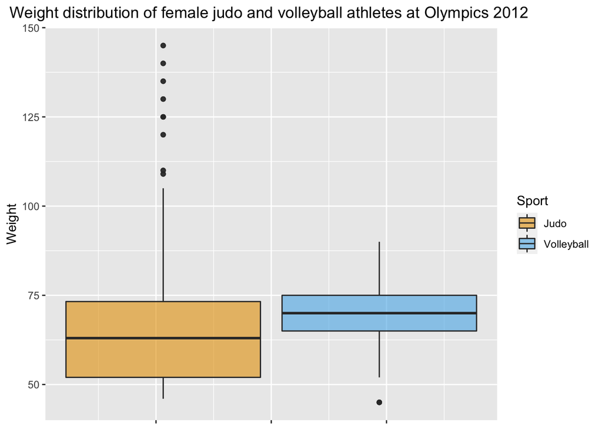

```r
judo_volleeball_boxplots <- ggplot(volleyball_judo_subset,aes(fill = Sport,y = Weight))+
  geom_boxplot(alpha=0.6)+
  ggtitle('Weight distribution of female judo and volleyball athletes at Olympics 2012 ')+
  scale_fill_manual(values=c("#E69F00","#56B4E9"))+
  theme(plot.title = element_text(hjust = 0.5))

judo_volleeball_boxplots + theme(axis.title.x=element_blank(),
                               axis.text.x=element_blank())
```

```r
shapiro.test(volleyball_judo_subset$Weight[volleyball_judo_subset$Sport == 'Volleyball'])
```

```
##
##  Shapiro-Wilk normality test
##
## data:  volleyball_judo_subset$Weight[volleyball_judo_subset$Sport == "Volleyball"]
## W = 0.98923, p-value = 0.003042
```

```r
shapiro.test(volleyball_judo_subset$Weight[volleyball_judo_subset$Sport == 'Judo'])
```

```
##
##  Shapiro-Wilk normality test
##
## data:  volleyball_judo_subset$Weight[volleyball_judo_subset$Sport == "Judo"]
## W = 0.80146, p-value < 2.2e-16
```

So, let’s use non-parametric U-test:

```r
wilcox.test(volleyball_judo_subset$Weight[volleyball_judo_subset$Sport == 'Judo'],
            volleyball_judo_subset$Weight[volleyball_judo_subset$Sport == 'Volleyball'])
```

```
##
##  Wilcoxon rank sum test with continuity correction
##
## data:  volleyball_judo_subset$Weight[volleyball_judo_subset$Sport == "Judo"] and volleyball_judo_subset$Weight[volleyball_judo_subset$Sport == "Volleyball"]
## W = 70506, p-value = 6.16e-13
## alternative hypothesis: true location shift is not equal to 0
```

## Use the following code to write the full data set to a new file .csv

```r
write.csv(olympic_games,file = paste0(working_dir,'full_olympiads.csv'))
```